# Wine Quality Analysis

Ryan Naidoo

2025-06-26

# Analysis of the physio-chemical qualities of wine

## We begin with the mutation of our data-set so that we have a column that tells us whether wine is good or not

```r
data <- read.csv("winequality-red.csv", sep = ",", header = TRUE) #read in the dataset that we are working with

data <- data %>% #Build that additionally column using the
mutate(is_good = ifelse(quality >= 7, "Good", "Not Good"))


#We now have a comparison metric that we may use to check whether wine is good or not
```

## Let us do some simple EDA.

### I expect that for alchohol quality, residual sugar content and pH are some important factors in determining whether wine is good or not. Let us plot a scatterplot and investigate the lines of best fit, aswell as assesssing the correlations. This will give us a base understanding of which one of these variables is the most important in the quality of red wine.

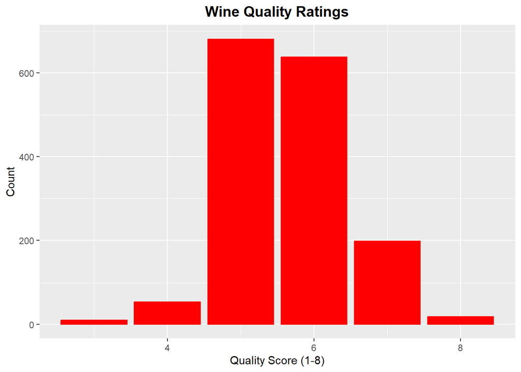

```r
#Bar graph showing wine ratings per quality.
ggplot(data, aes(x=quality)) +
  geom_bar(color = "red", fill = "red") +
  ggtitle("Distribution of Wine Quality Ratings") +  theme(plot.title = element_text(size = 14, face = "bold", hjust = 0.5)) + labs(title = "Wine Quality Ratings",
       x = "Quality Score (1-8)",
       y = "Count")
```

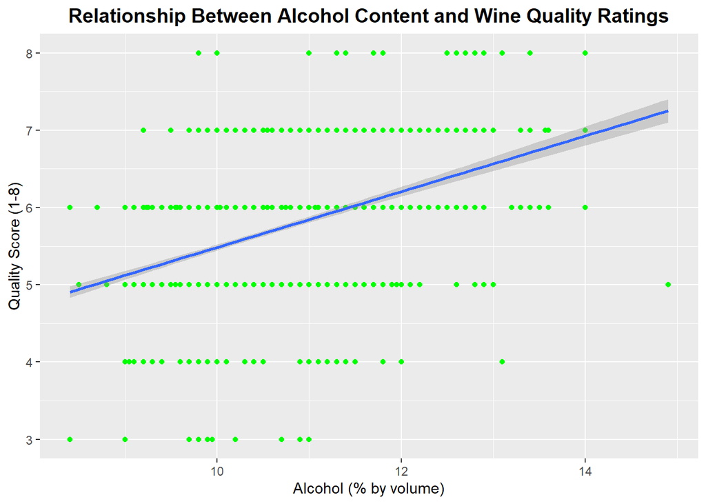

```r
# Alchohol and Quality relationship, line of best fit also provided.
ggplot(data, aes(x=alcohol, y=quality)) +
  geom_point(color = "green") +
  geom_smooth(method="lm") + labs(title = "Relationship Between Alcohol Content and Wine Quality Ratings",
       x = "Alcohol (% by volume)",
       y = "Quality Score (1-8)") + theme(plot.title = element_text(size = 14, face = "bold", hjust = 0.5))
```

```r
#Assessing the correlation of alchohol and quality
cor(data$alcohol, data$quality)
```

```
## [1] 0.4761663
```

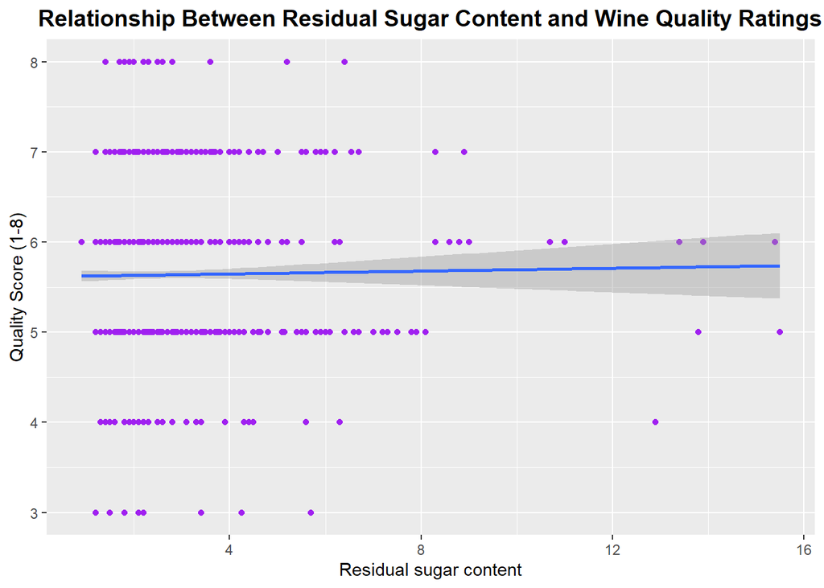

```r
#Residual sugar content and wine quality relationship

ggplot(data, aes(x=residual.sugar, y=quality)) +
  geom_point(color = "purple") +
  geom_smooth(method="lm") + labs(title = "Relationship Between Residual Sugar Content and Wine Quality Ratings",
       x = "Residual sugar content",
       y = "Quality Score (1-8)") + theme(plot.title = element_text(size = 14, face = "bold", hjust = 0.5))
```

```r
#Assessing the correlation of residual sugar and quality

cor(data$residual.sugar, data$quality)
```

```
## [1] 0.01373164
```

[figure not shown]

```r
#Investigating the relationship of ph and quality

ggplot(data, aes(x=pH, y=quality)) +
  geom_point(color = "orange") +
  geom_smooth(method="lm") + labs(title = "Relationship Between Residual Sugar Content and Wine Quality Ratings",
       x = "Residual sugar content",
       y = "Quality Score (1-8)") + theme(plot.title = element_text(size = 14, face = "bold", hjust = 0.5))
```

```r
cor(data$pH, data$quality)
```

```
## [1] -0.05773139
```